# Analysis of IIJA Funding Allocation

Souleymane Doumbia

2024-10-06

# Introduction

This report examines the allocation of the Infrastructure Investment and Jobs Act (IIJA) funding across U.S. states and territories. The analysis addresses two key questions:

1. Is the allocation equitable based on the population and infrastructure needs of the states, or is there evidence of bias?
2. Does the allocation favor the political interests of the Biden administration?

# Data Overview

The dataset includes:

- IIJA funding allocation per state as of March 2023
- Population estimates as of July 1, 2023
- Infrastructure grades from the ASCE
- Unemployment rates as of March 2023
- Political affiliation of each state based on the 2020 presidential election

# Proportion of Total Funding by Political Affiliation:

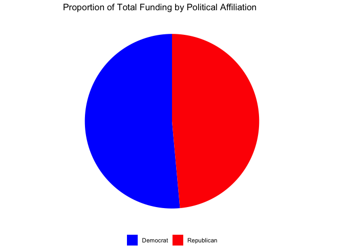

# Total Funding by State and Infrastructure Grade:

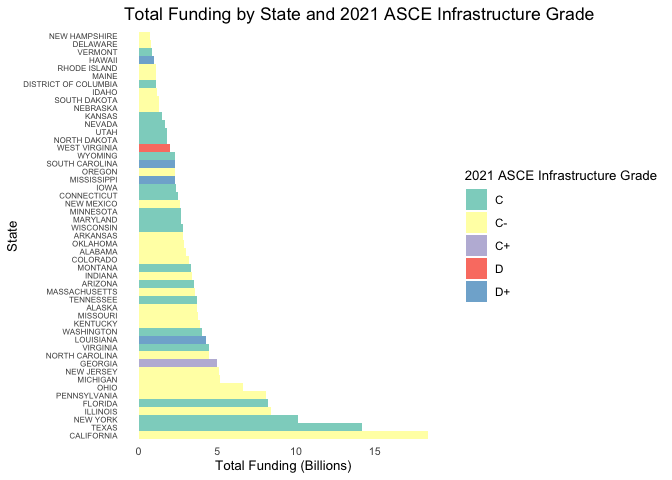

# Per Capita Funding by Political Affiliation:

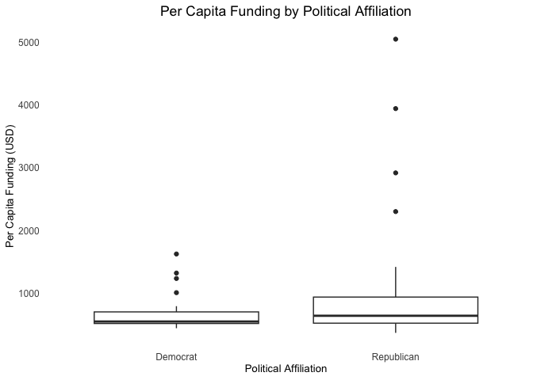

# Correlation Matrix:

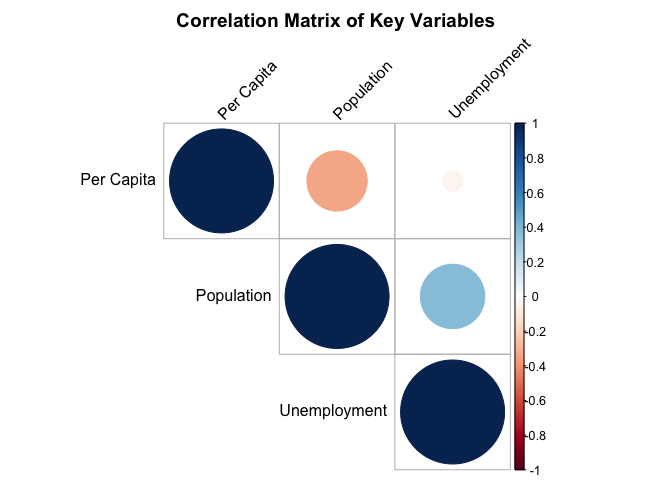

# Conclusion

The analysis reveals:

- **No clear partisan bias:** Republican states receive more per capita funding despite being fewer in number, which indicates no favoritism toward Democratic states.
- **Weak correlation between funding and infrastructure or unemployment:** Infrastructure needs and unemployment rates are not strongly correlated with funding, suggesting other factors may influence the allocation.
- **Funding allocation based on per capita differences:** States vary significantly in their per capita funding, with Republican states tending to receive more.

# Sources:

- **U.S. BUREAU OF LABOR STATISTICS (BLS)** for Unemployment Rates per State**:** https://www.bls.gov/lau/
- **AMERICAN SOCIETY OF CIVIL ENGINEERS (ASCE)** for Infrastructure Grades per State**:** https://infrastructurereportcard.org
- **UNITED STATES CENSUS BUREAU** for Population Estimates per State**:** https://www.census.gov/data/tables/time-series/demo/popest/2020s-state-total.html
- **THE NEW YORK TIMES** for 2020 Presidential Election Results**:** https://www.nytimes.com/interactive/2020/11/03/us/elections/results-president.html?action=click&pgtype=Article&state=default&module=styln-elections-2020&region=TOP_BANNER&context=election_recirc